# A1

### Project sequence

Data Overiview -> EDA -> Feature Engineering -> Model Development -> Model Evaluation

The goal of this project is to predict customer churn, represented by the binary variable Exited. An Exited value of 1 indicates that the customer has left the bank, while 0 indicates they remain active. Our models aim to identify customers at risk of churn so that retention strategies can be implemented proactively.

```python
import pandas as pd
import matplotlib.pyplot as plt
import seaborn as sns
import numpy as np
from sklearn.preprocessing import OneHotEncoder
from sklearn.compose import ColumnTransformer
from sklearn.pipeline import Pipeline
from sklearn.preprocessing import StandardScaler
```

import dataset

```python
path = "/Users/imparker/Documents/Bristol /Year 2/Machine-learning/Churn_Modelling.csv"
df = pd.read_csv(path)
```

## EDA

#### overall understanding of data structures

```python
df.info()
df.describe()
```

```
<class 'pandas.core.frame.DataFrame'>
RangeIndex: 10000 entries, 0 to 9999
Data columns (total 14 columns):
 #   Column           Non-Null Count  Dtype
---  ------           --------------  -----
 0   RowNumber        10000 non-null  int64
 1   CustomerId       10000 non-null  int64
 2   Surname          10000 non-null  object
 3   CreditScore      10000 non-null  int64
 4   Geography        10000 non-null  object
 5   Gender           10000 non-null  object
 6   Age              10000 non-null  int64
 7   Tenure           10000 non-null  int64
 8   Balance          10000 non-null  float64
 9   NumOfProducts    10000 non-null  int64
 10  HasCrCard        10000 non-null  int64
 11  IsActiveMember   10000 non-null  int64
 12  EstimatedSalary  10000 non-null  float64
 13  Exited           10000 non-null  int64
dtypes: float64(2), int64(9), object(3)
memory usage: 1.1+ MB
None
         RowNumber    CustomerId   CreditScore           Age        Tenure  \
count  10000.00000  1.000000e+04  10000.000000  10000.000000  10000.000000
mean    5000.50000  1.569094e+07    650.528800     38.921800      5.012800
std     2886.89568  7.193619e+04     96.653299     10.487806      2.892174
min        1.00000  1.556570e+07    350.000000     18.000000      0.000000
25%     2500.75000  1.562853e+07    584.000000     32.000000      3.000000
50%     5000.50000  1.569074e+07    652.000000     37.000000      5.000000
75%     7500.25000  1.575323e+07    718.000000     44.000000      7.000000
max    10000.00000  1.581569e+07    850.000000     92.000000     10.000000

             Balance  NumOfProducts    HasCrCard  IsActiveMember  \
count   10000.000000   10000.000000  10000.00000    10000.000000
mean    76485.889288       1.530200      0.70550        0.515100
std     62397.405202       0.581654      0.45584        0.499797
min         0.000000       1.000000      0.00000        0.000000
25%         0.000000       1.000000      0.00000        0.000000
50%     97198.540000       1.000000      1.00000        1.000000
75%    127644.240000       2.000000      1.00000        1.000000
max    250898.090000       4.000000      1.00000        1.000000

       EstimatedSalary        Exited
count     10000.000000  10000.000000
mean     100090.239881      0.203700
std       57510.492818      0.402769
min          11.580000      0.000000
25%       51002.110000      0.000000
50%      100193.915000      0.000000
75%      149388.247500      0.000000
max      199992.480000      1.000000
```

```python
print(df.isnull().sum())
```

```
RowNumber          0
CustomerId         0
Surname            0
CreditScore        0
Geography          0
Gender             0
Age                0
Tenure             0
Balance            0
NumOfProducts      0
HasCrCard          0
IsActiveMember     0
EstimatedSalary    0
Exited             0
dtype: int64
```

#### Drop RowNumber (Index information is of no significance for prediction), CustomerId (Unique identifier, does not represent customer behavior),Surname (Personal information cannot be generalized and may also lead to deviations). Keep Geography and Gender to perfrom One-Hot Encoding

```python
df = df.drop(['RowNumber', 'CustomerId', 'Surname'], axis=1)
```

```python
print(df.head())
print(df.columns)
```

```
   CreditScore Geography  Gender  Age  Tenure    Balance  NumOfProducts  \
0          619    France  Female   42       2       0.00              1
1          608     Spain  Female   41       1   83807.86              1
2          502    France  Female   42       8  159660.80              3
3          699    France  Female   39       1       0.00              2
4          850     Spain  Female   43       2  125510.82              1

   HasCrCard  IsActiveMember  EstimatedSalary  Exited
0          1               1        101348.88       1
1          0               1        112542.58       0
2          1               0        113931.57       1
3          0               0         93826.63       0
4          1               1         79084.10       0
Index(['CreditScore', 'Geography', 'Gender', 'Age', 'Tenure', 'Balance',
       'NumOfProducts', 'HasCrCard', 'IsActiveMember', 'EstimatedSalary',
       'Exited'],
      dtype='object')
```

#### Univariate analysis (looking at distribution characteristics)

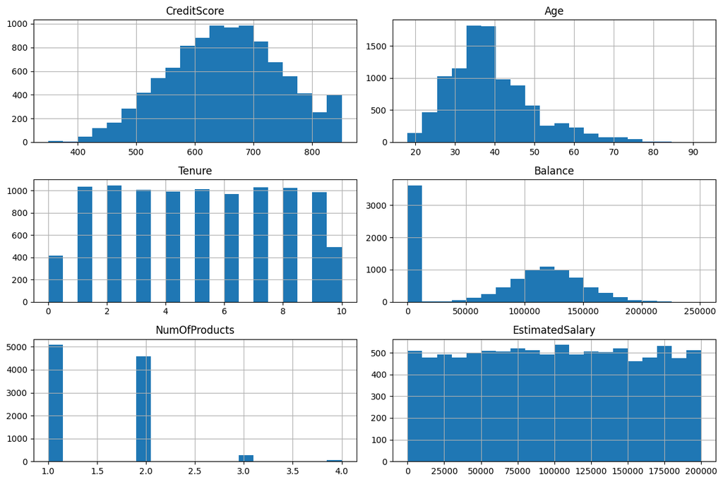

```python
numeric_cols = ['CreditScore', 'Age', 'Tenure', 'Balance', 'NumOfProducts', 'EstimatedSalary']

plt.figure(figsize=(12,8))
df[numeric_cols].hist(bins=20, figsize=(12,8))
plt.tight_layout()
plt.show()
```

#### Bivariate Analysis,looking at the relationship between each feature and the target Exited.

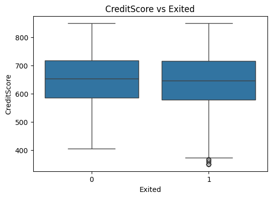

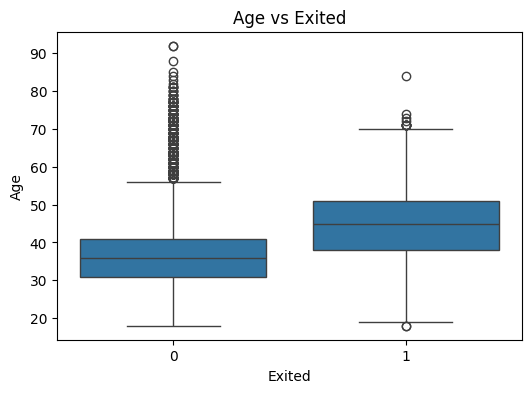

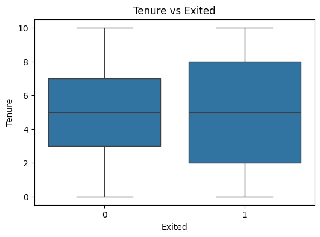

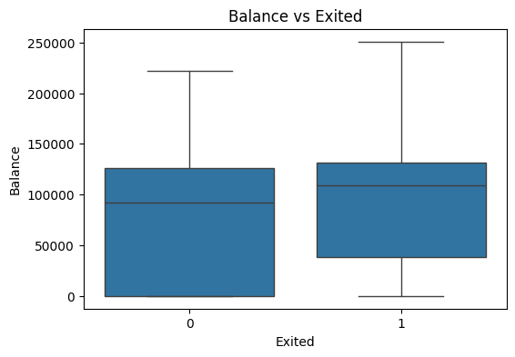

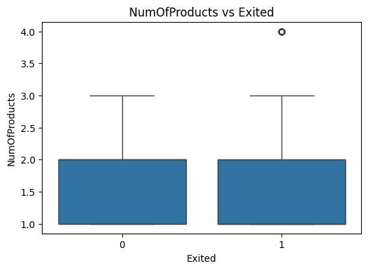

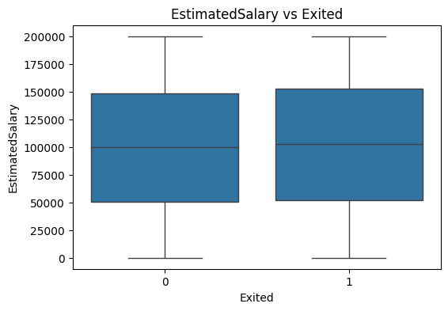

```python
for col in ['CreditScore','Age','Tenure','Balance','NumOfProducts','EstimatedSalary']:
    plt.figure(figsize=(6,4))
    sns.boxplot(x='Exited', y=col, data=df)
    plt.title(f'{col} vs Exited')
    plt.show()
```

#### Correlation heat map

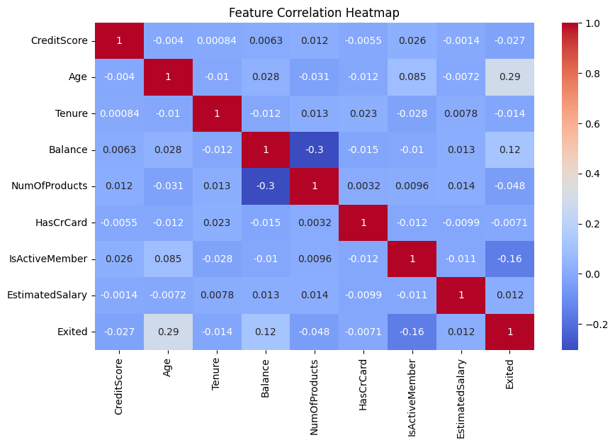

```python
corr = df.corr(numeric_only=True)
plt.figure(figsize=(10,6))
sns.heatmap(corr, cmap='coolwarm', annot=True)
plt.title("Feature Correlation Heatmap")
plt.show()
```

#### Multivariate Insights (Combinatorial relationships)-See if the "gender combination of a certain country" has a particularly high attrition rate.

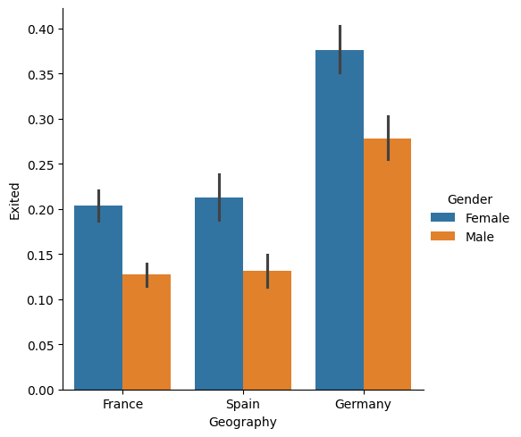

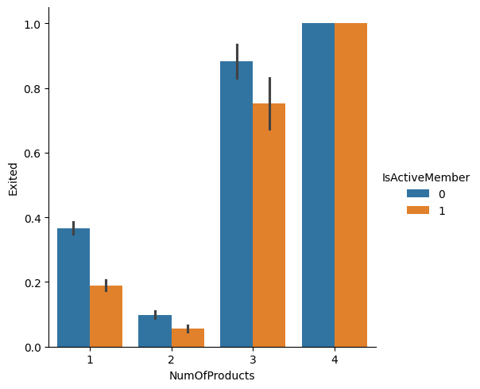

```python
sns.catplot(x='Geography', y='Exited', hue='Gender', data=df, kind='bar')
sns.catplot(x='NumOfProducts', y='Exited', hue='IsActiveMember', data=df, kind='bar')
```

#### === Outlier Detection & Visualization ===

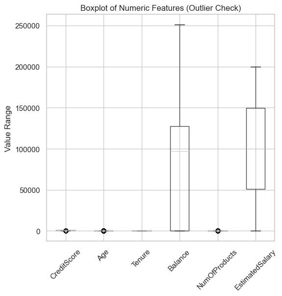

|  | Lower Bound | Upper Bound | Outlier Count | Outlier % |
| --- | --- | --- | --- | --- |
| CreditScore | 383.00 | 919.00 | 15.0 | 0.15 |
| Age | 14.00 | 62.00 | 359.0 | 3.59 |
| Tenure | -3.00 | 13.00 | 0.0 | 0.00 |
| Balance | -191466.36 | 319110.60 | 0.0 | 0.00 |
| NumOfProducts | -0.50 | 3.50 | 60.0 | 0.60 |
| EstimatedSalary | -96577.10 | 296967.45 | 0.0 | 0.00 |

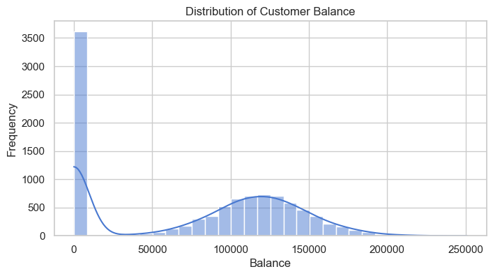

```python
import pandas as pd
import matplotlib.pyplot as plt
import seaborn as sns

num_cols = ['CreditScore', 'Age', 'Tenure', 'Balance',
            'NumOfProducts', 'EstimatedSalary']

plt.figure(figsize=(12, 6))
df[num_cols].boxplot()
plt.title("Boxplot of Numeric Features (Outlier Check)")
plt.ylabel("Value Range")
plt.xticks(rotation=45)
plt.show()

outlier_summary = {}
for col in num_cols:
    Q1 = df[col].quantile(0.25)
    Q3 = df[col].quantile(0.75)
    IQR = Q3 - Q1
    lower = Q1 - 1.5 * IQR
    upper = Q3 + 1.5 * IQR
    outliers = ((df[col] < lower) | (df[col] > upper)).sum()
    outlier_summary[col] = {
        "Lower Bound": round(lower, 2),
        "Upper Bound": round(upper, 2),
        "Outlier Count": int(outliers),
        "Outlier %": round(outliers / len(df) * 100, 2)
    }

outlier_df = pd.DataFrame(outlier_summary).T
display(outlier_df)

plt.figure(figsize=(8,4))
sns.histplot(df['Balance'], bins=30, kde=True)
plt.title("Distribution of Customer Balance")
plt.xlabel("Balance")
plt.ylabel("Frequency")
plt.show()
```

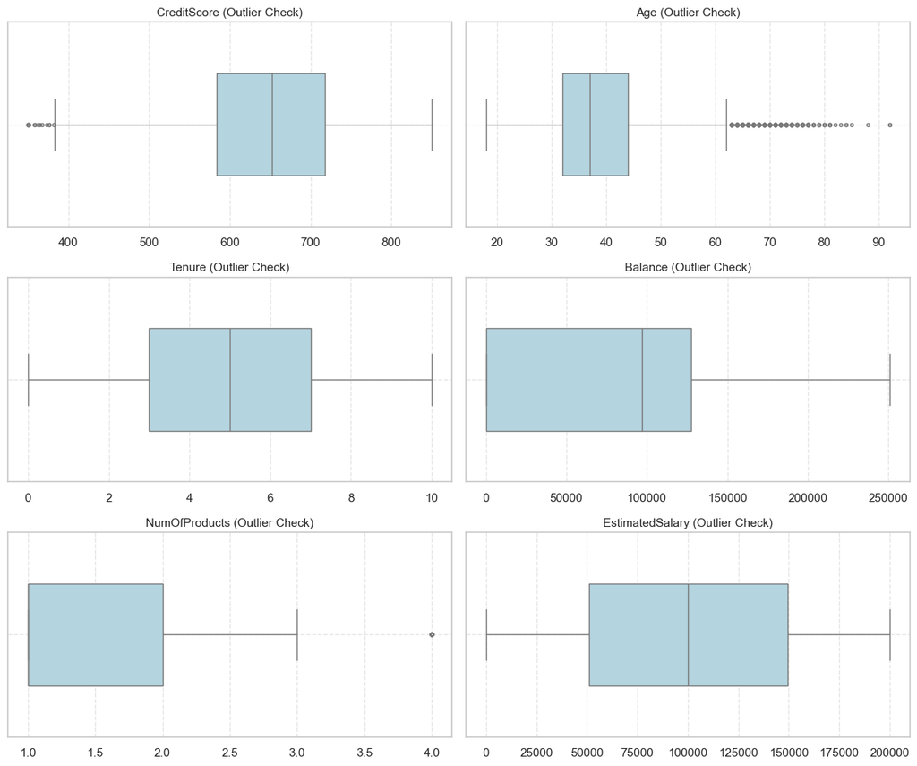

```python
import matplotlib.pyplot as plt
import seaborn as sns

num_cols = ['CreditScore', 'Age', 'Tenure', 'Balance', 'NumOfProducts', 'EstimatedSalary']

plt.figure(figsize=(12, 10))
for i, col in enumerate(num_cols, 1):
    plt.subplot(3, 2, i)
    sns.boxplot(x=df[col], color='lightblue', fliersize=3, width=0.5)
    plt.title(f"{col} (Outlier Check)", fontsize=11)
    plt.xlabel("")
    plt.grid(True, linestyle='--', alpha=0.5)
plt.tight_layout()
plt.show()
```

#### EDA Summary:

1. Data Cleaning

Dropped: RowNumber, CustomerId, Surname (no predictive value).

Retained key features: demographics, activity, and account metrics.

No missing values detected.

2. Univariate Insights

CreditScore ~ normal around 650–700 → most customers are mid-credit.

Age right-skewed (30–40 dominant) → older clients more prone to churn.

Tenure roughly uniform (0–10).

Balance highly skewed → many zero-balance accounts.

NumOfProducts discrete (1–2 mostly).

EstimatedSalary roughly uniform → weak signal expected.

3. Bivariate Insights (vs Exited)

German customers have the highest churn rate; French the lowest.

CreditScore & Salary show weak influence on churn.

4. Correlation Highlights

Age positively correlates with churn (~0.28).

IsActiveMember negatively correlates with churn (~–0.15).

No severe multicollinearity among numeric features.

5. Key Takeaways

Main drivers: Age, Activity Status, Geography, Product count.

Weak drivers: CreditScore, Salary, Tenure.